# R Notebook

```
Rows: 18
Columns: 5
$ hb               <chr> "S08000015", "S08000016", "S08000017", "S08000018", "S08000019", "S08000020", "S08000021", "S08000022", "S08~
$ hb_name          <chr> "NHS Ayrshire and Arran", "NHS Borders", "NHS Dumfries and Galloway", "NHS Fife", "NHS Forth Valley", "NHS G~
$ hb_date_enacted  <dbl> 20140401, 20140401, 20140401, 20140401, 20140401, 20140401, 20140401, 20140401, 20140401, 20140401, 20140401~
$ hb_date_archived <dbl> NA, NA, NA, 20180201, NA, NA, 20190331, NA, 20190331, NA, NA, NA, 20180201, NA, NA, NA, NA, NA
$ country          <chr> "S92000003", "S92000003", "S92000003", "S92000003", "S92000003", "S92000003", "S92000003", "S92000003", "S92~
```

```
Rows: 408
Columns: 61
$ region                                   <chr> "North of Scotland", "North of Scotland", "North of Scotland", "North of Scotland", ~
$ cancer_site_icd10code                    <chr> "C00-C97, excluding C44", "C00-C97, excluding C44", "C00-C97, excluding C44", "C67",~
$ cancer_site                              <chr> "All cancer types", "All cancer types", "All cancer types", "Bladder", "Bladder", "B~
$ sex                                      <chr> "All", "Male", "Female", "All", "Male", "Female", "All", "Male", "Female", "All", "M~
$ sex_qf                                   <chr> "d", NA, NA, "d", NA, NA, "d", NA, NA, "d", NA, NA, "d", NA, NA, "d", NA, NA, "d", N~
$ year                                     <chr> "2015-2019", "2015-2019", "2015-2019", "2015-2019", "2015-2019", "2015-2019", "2015-~
$ incidences_age_under5                    <dbl> 86, 47, 39, 0, 0, 0, 1, 1, 0, 4, 2, 2, 3, 1, 2, 13, 9, 4, 15, 11, 4, 3, 3, 0, 18, 14~
$ incidences_age5to9                       <dbl> 61, 33, 28, 0, 0, 0, 2, 1, 1, 3, 1, 2, 1, 0, 1, 17, 8, 9, 19, 8, 11, 7, 3, 4, 26, 11~
$ incidences_age10to14                     <dbl> 46, 28, 18, 0, 0, 0, 5, 4, 1, 10, 5, 5, 5, 1, 4, 2, 2, 0, 3, 2, 1, 2, 2, 0, 5, 4, 1,~
$ incidences_age15to19                     <dbl> 78, 37, 41, 0, 0, 0, 4, 3, 1, 9, 6, 3, 5, 3, 2, 5, 5, 0, 8, 7, 1, 4, 1, 3, 12, 8, 4,~
$ incidences_age20to24                     <dbl> 126, 60, 66, 0, 0, 0, 3, 2, 1, 4, 3, 1, 1, 1, 0, 5, 1, 4, 6, 1, 5, 14, 5, 9, 20, 6, ~
$ incidences_age25to29                     <dbl> 243, 97, 146, 0, 0, 0, 4, 3, 1, 8, 6, 2, 4, 3, 1, 15, 7, 8, 17, 8, 9, 8, 3, 5, 25, 1~
$ incidences_age30to34                     <dbl> 444, 147, 297, 2, 1, 1, 2, 2, 0, 6, 4, 2, 4, 2, 2, 21, 10, 11, 22, 11, 11, 17, 10, 7~
```

[output cut: 48 more lines]

```
Rows: 47,600
Columns: 23
$ hb                                       <chr> "Ayrshire and Arran", "Ayrshire and Arran", "Ayrshire and Arran", "Ayrshire and Arr~
$ cancer_site_icd10code                    <chr> "C00-C97, excluding C44", "C00-C97, excluding C44", "C00-C97, excluding C44", "C00-~
$ cancer_site                              <chr> "All cancer types", "All cancer types", "All cancer types", "All cancer types", "Al~
$ sex                                      <chr> "All", "All", "All", "All", "All", "All", "All", "All", "All", "All", "All", "All",~
$ sex_qf                                   <chr> "d", "d", "d", "d", "d", "d", "d", "d", "d", "d", "d", "d", "d", "d", "d", "d", "d"~
$ year                                     <dbl> 1995, 1996, 1997, 1998, 1999, 2000, 2001, 2002, 2003, 2004, 2005, 2006, 2007, 2008,~
$ incidences_all_ages                      <dbl> 1839, 2014, 2019, 1958, 1966, 1942, 1989, 2043, 2142, 2184, 2124, 2108, 2195, 2308,~
$ crude_rate                               <dbl> 491.4353, 539.7293, 541.6499, 526.6414, 530.5484, 526.6155, 540.0635, 555.9184, 582~
$ crude_rate_lower95pc_confidence_interval <dbl> 469.2287, 516.4123, 518.2786, 503.5703, 507.3529, 503.4518, 516.5875, 532.0711, 558~
$ crude_rate_upper95pc_confidence_interval <dbl> 514.4214, 563.8279, 565.8035, 550.4969, 554.5308, 550.5701, 564.3314, 580.5590, 607~
$ easr                                     <dbl> 604.7250, 645.8993, 653.6445, 621.0194, 628.6583, 611.9952, 618.4834, 645.9641, 651~
$ easr_lower95pc_confidence_interval       <dbl> 575.6889, 616.8180, 623.8632, 592.4901, 599.7664, 583.8276, 590.3419, 616.8148, 623~
$ easr_lower95pc_confidence_interval_qf    <chr> NA, NA, NA, NA, NA, NA, NA, NA, NA, NA, NA, NA, NA, NA, NA, NA, NA, NA, NA, NA, NA,~
$ easr_upper95pc_confidence_interval       <dbl> 634.4654, 675.6410, 684.1104, 650.2101, 658.2202, 640.8172, 647.2709, 675.7769, 680~
$ easr_upper95pc_confidence_interval_qf    <chr> NA, NA, NA, NA, NA, NA, NA, NA, NA, NA, NA, NA, NA, NA, NA, NA, NA, NA, NA, NA, NA,~
$ wasr                                     <dbl> 275.9170, 303.4057, 295.3486, 286.0872, 288.1310, 281.6776, 282.2357, 283.8874, 297~
$ wasr_lower95pc_confidence_interval       <dbl> 262.4022, 289.1865, 281.5199, 272.4115, 274.3408, 267.9613, 268.7769, 270.4715, 283~
$ wasr_lower95pc_confidence_interval_qf    <chr> NA, NA, NA, NA, NA, NA, NA, NA, NA, NA, NA, NA, NA, NA, NA, NA, NA, NA, NA, NA, NA,~
$ wasr_upper95pc_confidence_interval       <dbl> 289.7665, 317.9614, 309.5041, 300.0930, 302.2546, 295.7315, 296.0186, 297.6236, 311~
$ wasr_upper95pc_confidence_interval_qf    <chr> NA, NA, NA, NA, NA, NA, NA, NA, NA, NA, NA, NA, NA, NA, NA, NA, NA, NA, NA, NA, NA,~
$ standardised_incidence_ratio             <dbl> 93.08757, 96.01580, 99.95725, 98.52850, 98.58895, 96.14664, 98.18593, 98.53440, 101~
$ sir_lower95pc_confidence_interval        <dbl> 88.88121, 91.86779, 95.64426, 94.21216, 94.27867, 91.91753, 93.91788, 94.30757, 97.~
$ sir_upper95pc_confidence_interval        <dbl> 97.44158, 100.30284, 104.41462, 102.99159, 103.04548, 100.52015, 102.59793, 102.901~
```

```
Rows: 3,400
Columns: 60
$ country                                  <chr> "S92000003", "S92000003", "S92000003", "S92000003", "S92000003", "S92000003", "S920~
$ cancer_site_icd10code                    <chr> "C00-C97, excluding C44", "C00-C97, excluding C44", "C00-C97, excluding C44", "C00-~
$ cancer_site                              <chr> "All cancer types", "All cancer types", "All cancer types", "All cancer types", "Al~
$ sex                                      <chr> "All", "All", "All", "All", "All", "All", "All", "All", "All", "All", "All", "All",~
$ sex_qf                                   <chr> "d", "d", "d", "d", "d", "d", "d", "d", "d", "d", "d", "d", "d", "d", "d", "d", "d"~
$ year                                     <dbl> 1995, 1996, 1997, 1998, 1999, 2000, 2001, 2002, 2003, 2004, 2005, 2006, 2007, 2008,~
$ incidences_age_under5                    <dbl> 56, 58, 57, 59, 56, 44, 56, 62, 58, 51, 54, 51, 54, 61, 51, 44, 52, 54, 57, 59, 65,~
$ incidences_age5to9                       <dbl> 39, 19, 38, 25, 28, 35, 31, 39, 43, 41, 22, 21, 31, 38, 23, 17, 31, 32, 23, 43, 33,~
$ incidences_age10to14                     <dbl> 40, 28, 38, 35, 31, 27, 36, 51, 38, 46, 36, 26, 21, 31, 32, 32, 33, 32, 30, 26, 31,~
$ incidences_age15to19                     <dbl> 51, 55, 57, 57, 51, 47, 51, 61, 78, 55, 60, 60, 67, 59, 67, 56, 61, 58, 65, 66, 67,~
$ incidences_age20to24                     <dbl> 95, 106, 113, 89, 90, 99, 113, 106, 96, 99, 119, 113, 101, 115, 118, 133, 119, 108,~
$ incidences_age25to29                     <dbl> 189, 213, 194, 176, 179, 187, 156, 169, 144, 157, 156, 155, 175, 203, 205, 208, 211~
$ incidences_age30to34                     <dbl> 301, 302, 316, 305, 302, 299, 280, 296, 298, 257, 248, 266, 287, 259, 245, 290, 256~
```

[output cut: 47 more lines]

| hb | cancer_site_icd10code | cancer_site | sex | sex_qf | year | incidences_all_ages | crude_rate | crude_rate_lower95pc_confidence_interval | crude_rate_upper95pc_confidence_interval | easr | easr_lower95pc_confidence_interval | easr_lower95pc_confidence_interval_qf | easr_upper95pc_confidence_interval | easr_upper95pc_confidence_interval_qf | wasr | wasr_lower95pc_confidence_interval | wasr_lower95pc_confidence_interval_qf | wasr_upper95pc_confidence_interval | wasr_upper95pc_confidence_interval_qf | standardised_incidence_ratio | sir_lower95pc_confidence_interval | sir_upper95pc_confidence_interval |
| --- | --- | --- | --- | --- | --- | --- | --- | --- | --- | --- | --- | --- | --- | --- | --- | --- | --- | --- | --- | --- | --- | --- |
| Ayrshire and Arran | C00-C97, excluding C44 | All cancer types | All | d | 1995 | 1839 | 491.4353 | 469.2287 | 514.4214 | 604.7250 | 575.6889 | NA | 634.4654 | NA | 275.9170 | 262.4022 | NA | 289.7665 | NA | 93.08757 | 88.88121 | 97.44158 |
| Ayrshire and Arran | C00-C97, excluding C44 | All cancer types | All | d | 1996 | 2014 | 539.7293 | 516.4123 | 563.8279 | 645.8993 | 616.8180 | NA | 675.6410 | NA | 303.4057 | 289.1865 | NA | 317.9614 | NA | 96.01580 | 91.86779 | 100.30284 |
| Ayrshire and Arran | C00-C97, excluding C44 | All cancer types | All | d | 1997 | 2019 | 541.6499 | 518.2786 | 565.8035 | 653.6445 | 623.8632 | NA | 684.1104 | NA | 295.3486 | 281.5199 | NA | 309.5041 | NA | 99.95725 | 95.64426 | 104.41462 |
| Ayrshire and Arran | C00-C97, excluding C44 | All cancer types | All | d | 1998 | 1958 | 526.6414 | 503.5703 | 550.4969 | 621.0194 | 592.4901 | NA | 650.2101 | NA | 286.0872 | 272.4115 | NA | 300.0930 | NA | 98.52850 | 94.21216 | 102.99159 |
| Ayrshire and Arran | C00-C97, excluding C44 | All cancer types | All | d | 1999 | 1966 | 530.5484 | 507.3529 | 554.5308 | 628.6583 | 599.7664 | NA | 658.2202 | NA | 288.1310 | 274.3408 | NA | 302.2546 | NA | 98.58895 | 94.27867 | 103.04548 |
| Ayrshire and Arran | C00-C97, excluding C44 | All cancer types | All | d | 2000 | 1942 | 526.6155 | 503.4518 | 550.5701 | 611.9952 | 583.8276 | NA | 640.8172 | NA | 281.6776 | 267.9613 | NA | 295.7315 | NA | 96.14664 | 91.91753 | 100.52015 |

```
 [1] "Ayrshire and Arran"        "Borders"                   "Dumfries and Galloway"     "Fife"
 [5] "Forth Valley"              "Grampian"                  "Greater Glasgow and Clyde" "Highland"
 [9] "Lanarkshire"               "Lothian"                   "Orkney"                    "Shetland"
[13] "Tayside"                   "Western Isles"
```

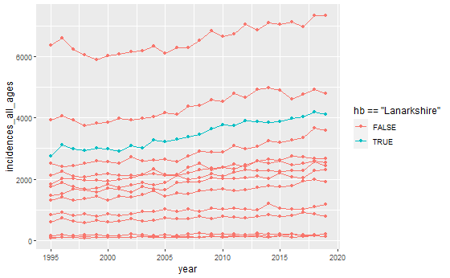

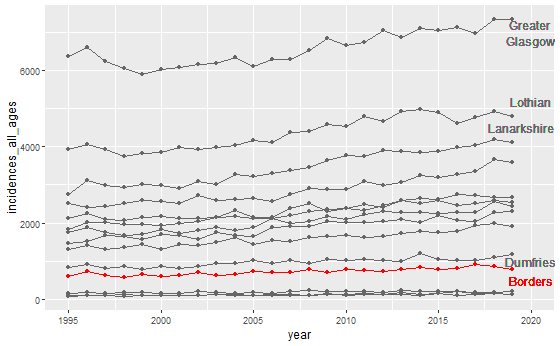

In comparison to other local Health Boards, NHS Borders has a small percentage of the cancer incidences across Scotland

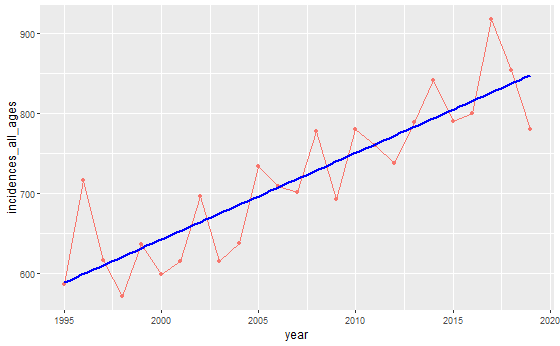

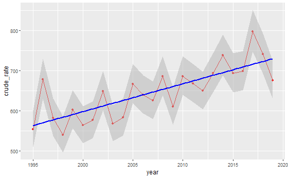

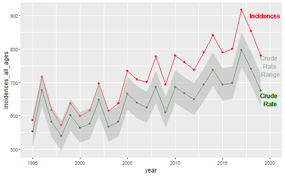

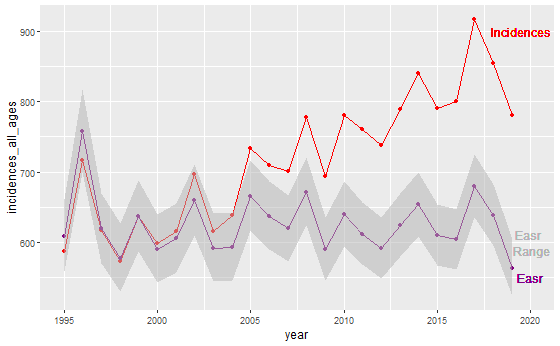

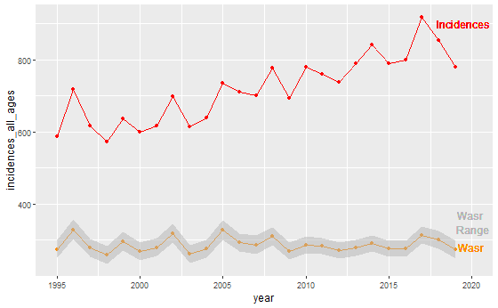

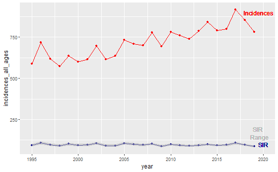

[output not shown]

[output cut: 990 more lines]

```
 [1] "All cancer types"                                             "Bladder"
 [3] "Bone and articular cartilage"                                 "Bone and connective tissue"
 [5] "Connective tissue"                                            "Malignant brain cancer"
 [7] "Malig brain ca (incl pit. gland, cranio. duct, pineal gland)" "Non-malig brain ca (incl pit.gland,cranio.duct,pineal gland)"
 [9] "All brain and CNS tumours (malignant and non-malignant)"      "Breast"
[11] "Carcinoma in situ of the breast"                              "Colorectal cancer"
[13] "Colon"                                                        "Rectum and rectosigmoid junction"
[15] "Cervix uteri"                                                 "Carcinoma in situ of the cervix uteri"
[17] "Corpus uteri"                                                 "Ovary"
[19] "Uterus"                                                       "Vagina"
[21] "Vulva"                                                        "Head and neck"
[23] "Larynx"                                                       "Lip, oral cavity and pharynx"
[25] "Mouth (IARC definition)"                                      "Oral cavity"
[27] "Salivary glands"                                              "Thyroid"
[29] "Tongue"                                                       "Oropharyngeal cancers"
[31] "Hodgkin lymphoma"                                             "Kidney"
[33] "Leukaemias"                                                   "Acute lymphoblastic leukaemia"
[35] "Acute myeloid leukaemia"                                      "Chronic lymphocytic leukaemia"
[37] "Chronic myeloid leukaemia"                                    "Liver and intrahepatic bile ducts"
[39] "Trachea, bronchus and lung"                                   "Mesothelioma"
[41] "Penis"                                                        "Prostate"
[43] "Testis"                                                       "Multiple myeloma and malignant plasma cell neoplasms"
[45] "Non-Hodgkin lymphoma"                                         "Oesophagus"
[47] "Pancreas"                                                     "Malignant melanoma of the skin"
[49] "Non-melanoma skin cancer"                                     "Basal cell carcinoma of the skin"
[51] "Squamous cell carcinoma of the skin"                          "Stomach"
```

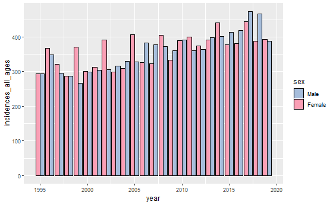

There’s not much difference between the genders, some spikes that can be explained below.

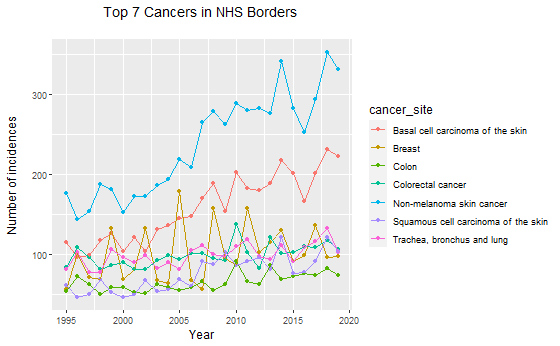

There are 51 tpyes of cancer that are recorded across Scotland. Out of all these types of cancer the majority have less than 50 cases a year in NHS Borders

Taking the top 7 types of cancer that are have more than 50 cases a year. They can be split by proactive and reactive approaches

#### Proactive

* We can see that three of them are based on skin cancers that have like developed from exposed to ultraviolet (UV) radiation from the sun. This can be combated with more publicity encouraging on when and how to using sunscreen, while in the local area or on holiday abroad.

* Trachea, bronchus and lung cancers, came mainly from direct or passive smoking. This can be combated with more publicity on the dangers of direct or passive smoking to people and their family. Can look at putting more support for people trying to quit.

#### Reactive

* 2 are types Bowel cancers, while the cause of these is not known, certain risk factors are strongly linked to the disease, including diet, tobacco smoking and heavy alcohol use.

* Breast cancer is caused when the DNA in breast cells mutate or change, disabling specific functions that control cell growth and division.

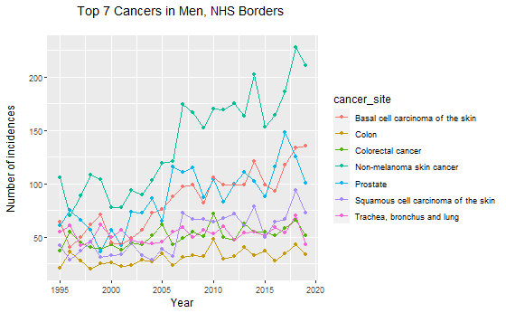

[output not shown]

[output cut: 990 more lines]

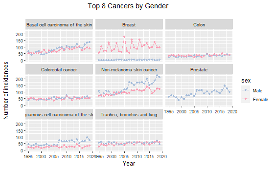

While almost all the cancers are shared equally between the two genders, two cancers breast and prostate have a traditional gender bias on which is effected. As-well two of the skin cancers have a higher risk in men since around 2005 on wards. This can be a demographic to target to focus the publicity encouraging talked about above or showing the risk

```
Rows: 1,496
Columns: 59
$ hb                                       <chr> "Ayrshire and Arran", "Ayrshire and Arran", "Ayrshire and Arran", "Ayrshire and Arr~
$ cancer_site_icd10code                    <chr> "C00-C97, excluding C44", "C00-C97, excluding C44", "C00-C97, excluding C44", "C67"~
$ cancer_site                              <chr> "All cancer types", "All cancer types", "All cancer types", "Bladder", "Bladder", "~
$ sex                                      <chr> "All", "Male", "Female", "All", "Male", "Female", "All", "Male", "Female", "All", "~
$ sex_qf                                   <chr> "d", NA, NA, "d", NA, NA, "d", NA, NA, "d", NA, NA, "d", NA, NA, "d", NA, NA, "d", ~
$ year                                     <chr> "2015-2019", "2015-2019", "2015-2019", "2015-2019", "2015-2019", "2015-2019", "2015~
$ incidences_age_under5                    <dbl> 13, 8, 5, 0, 0, 0, 0, 0, 0, 1, 1, 0, 1, 1, 0, 3, 1, 2, 3, 1, 2, 1, 1, 0, 4, 2, 2, 0~
$ incidences_age5to9                       <dbl> 10, 6, 4, 0, 0, 0, 0, 0, 0, 2, 1, 1, 2, 1, 1, 5, 3, 2, 5, 3, 2, 1, 0, 1, 6, 3, 3, 0~
$ incidences_age10to14                     <dbl> 13, 4, 9, 0, 0, 0, 2, 1, 1, 2, 1, 1, 0, 0, 0, 2, 1, 1, 2, 1, 1, 1, 0, 1, 3, 1, 2, 0~
$ incidences_age15to19                     <dbl> 25, 13, 12, 1, 1, 0, 2, 0, 2, 4, 0, 4, 2, 0, 2, 2, 1, 1, 2, 1, 1, 2, 2, 0, 4, 3, 1,~
$ incidences_age20to24                     <dbl> 33, 12, 21, 0, 0, 0, 1, 0, 1, 4, 0, 4, 3, 0, 3, 0, 0, 0, 0, 0, 0, 3, 3, 0, 3, 3, 0,~
$ incidences_age25to29                     <dbl> 69, 32, 37, 0, 0, 0, 0, 0, 0, 0, 0, 0, 0, 0, 0, 5, 3, 2, 5, 3, 2, 6, 2, 4, 11, 5, 6~
$ incidences_age30to34                     <dbl> 96, 26, 70, 0, 0, 0, 1, 0, 1, 2, 0, 2, 1, 0, 1, 4, 1, 3, 4, 1, 3, 8, 2, 6, 12, 3, 9~
```

[output cut: 46 more lines]

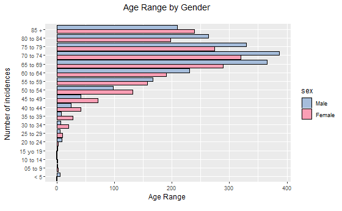

Here we can see the brake down by age and gender showing the older the person is the greater risk they have. While women start by being at higher risk at a younger age older men make up the highest risk of cancer. This adds these ages to the demographic of targets to focus any publicity for proactive and reactive approaches.

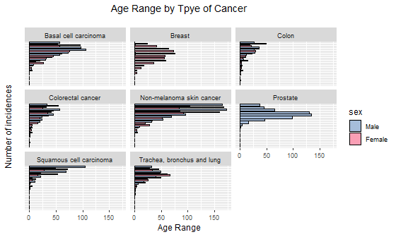

This is a brake down of Cancer type by age reinforces the demographic of targets to focus any publicity for proactive and reactive approaches.

- Skin and lung cancers both men and women being encouraged to take proactive while young.
- Breast and prostate cancers for women and men respectively should be checked regularly at these ages.